# NMF

**classsklearn.decomposition.NMF(*n_components='auto'*, *, *init=None*, *solver='cd'*, *beta_loss='frobenius'*, *tol=0.0001*, *max_iter=200*, *random_state=None*, *alpha_W=0.0*, *alpha_H='same'*, *l1_ratio=0.0*, *verbose=0*, *shuffle=False*)[[source]](https://github.com/scikit-learn/scikit-learn/blob/cc50648cc/sklearn/decomposition/_nmf.py#L1320)**

Non-Negative Matrix Factorization (NMF).

Find two non-negative matrices, i.e. matrices with all non-negative elements, (W, H) whose product approximates the non-negative matrix X. This factorization can be used for example for dimensionality reduction, source separation or topic extraction.

The objective function is:

$\begin{align}\begin{aligned}L(W, H) &= 0.5 * ||X - WH||_{loss}^2\\ &+ alpha\_W * l1\_ratio * n\_features * ||vec(W)||_1\\ &+ alpha\_H * l1\_ratio * n\_samples * ||vec(H)||_1\\ &+ 0.5 * alpha\_W * (1 - l1\_ratio) * n\_features * ||W||_{Fro}^2\\ &+ 0.5 * alpha\_H * (1 - l1\_ratio) * n\_samples * ||H||_{Fro}^2,\end{aligned}\end{align}$

where $||A||_{Fro}^2 = \sum_{i,j} A_{ij}^2$ (Frobenius norm) and $||vec(A)||_1 = \sum_{i,j} abs(A_{ij})$ (Elementwise L1 norm).

The generic norm $||X - WH||_{loss}$ may represent the Frobenius norm or another supported beta-divergence loss. The choice between options is controlled by the `beta_loss` parameter.

The regularization terms are scaled by `n_features` for `W` and by `n_samples` for `H` to keep their impact balanced with respect to one another and to the data fit term as independent as possible of the size `n_samples` of the training set.

The objective function is minimized with an alternating minimization of W and H.

Note that the transformed data is named W and the components matrix is named H. In the NMF literature, the naming convention is usually the opposite since the data matrix X is transposed.

Read more in the User Guide.

**Parameters:**

**n_components**int or {‘auto’} or None, default=’auto’**

Number of components. If `None`, all features are kept. If `n_components='auto'`, the number of components is automatically inferred from W or H shapes.

Changed in version 1.4: Added `'auto'` value.

Changed in version 1.6: Default value changed from `None` to `'auto'`.

**init**{‘random’, ‘nndsvd’, ‘nndsvda’, ‘nndsvdar’, ‘custom’}, default=None**

Method used to initialize the procedure. Valid options:

- `None`: ‘nndsvda’ if n_components <= min(n_samples, n_features), otherwise random.
- `'random'`: non-negative random matrices, scaled with: `sqrt(X.mean() / n_components)`
- `'nndsvd'`: Nonnegative Double Singular Value Decomposition (NNDSVD) initialization (better for sparseness)
- `'nndsvda'`: NNDSVD with zeros filled with the average of X (better when sparsity is not desired)
- `'nndsvdar'` NNDSVD with zeros filled with small random values (generally faster, less accurate alternative to NNDSVDa for when sparsity is not desired)
- `'custom'`: Use custom matrices `W` and `H` which must both be provided.

Changed in version 1.1: When `init=None` and n_components is less than n_samples and n_features defaults to `nndsvda` instead of `nndsvd`.

**solver**{‘cd’, ‘mu’}, default=’cd’**

Numerical solver to use:

- ‘cd’ is a Coordinate Descent solver.
- ‘mu’ is a Multiplicative Update solver.

Added in version 0.17: Coordinate Descent solver.

Added in version 0.19: Multiplicative Update solver.

**beta_loss**float or {‘frobenius’, ‘kullback-leibler’, ‘itakura-saito’}, default=’frobenius’**

Beta divergence to be minimized, measuring the distance between X and the dot product WH. Note that values different from ‘frobenius’ (or 2) and ‘kullback-leibler’ (or 1) lead to significantly slower fits. Note that for beta_loss <= 0 (or ‘itakura-saito’), the input matrix X cannot contain zeros. Used only in ‘mu’ solver.

Added in version 0.19.

**tol**float, default=1e-4**

Tolerance of the stopping condition.

**max_iter**int, default=200**

Maximum number of iterations before timing out.

**random_state**int, RandomState instance or None, default=None**

Used for initialisation (when `init` == ‘nndsvdar’ or ‘random’), and in Coordinate Descent. Pass an int for reproducible results across multiple function calls. See [Glossary](https://scikit-learn.org/1.9/glossary.html#term-random_state).

**alpha_W**float, default=0.0**

Constant that multiplies the regularization terms of `W`. Set it to zero (default) to have no regularization on `W`.

Added in version 1.0.

**alpha_H**float or “same”, default=”same”**

Constant that multiplies the regularization terms of `H`. Set it to zero to have no regularization on `H`. If “same” (default), it takes the same value as `alpha_W`.

Added in version 1.0.

**l1_ratio**float, default=0.0**

The regularization mixing parameter, with 0 <= l1_ratio <= 1. For l1_ratio = 0 the penalty is an elementwise L2 penalty (aka Frobenius Norm). For l1_ratio = 1 it is an elementwise L1 penalty. For 0 < l1_ratio < 1, the penalty is a combination of L1 and L2.

Added in version 0.17: Regularization parameter *l1_ratio* used in the Coordinate Descent solver.

**verbose**int, default=0**

Whether to be verbose.

**shuffle**bool, default=False**

If true, randomize the order of coordinates in the CD solver.

Added in version 0.17: *shuffle* parameter used in the Coordinate Descent solver.

**Attributes:**

**components_**ndarray of shape (n_components, n_features)**

Factorization matrix, sometimes called ‘dictionary’.

**n_components_**int**

The number of components. It is same as the `n_components` parameter if it was given. Otherwise, it will be same as the number of features.

**reconstruction_err_**float**

Frobenius norm of the matrix difference, or beta-divergence, between the training data `X` and the reconstructed data `WH` from the fitted model.

**n_iter_**int**

Actual number of iterations.

**n_features_in_**int**

Number of features seen during fit.

Added in version 0.24.

**feature_names_in_**ndarray of shape (`n_features_in_`,)**

Names of features seen during fit. Defined only when `X` has feature names that are all strings.

Added in version 1.0.

See also

**`DictionaryLearning`**

Find a dictionary that sparsely encodes data.

**`MiniBatchSparsePCA`**

Mini-batch Sparse Principal Components Analysis.

**`PCA`**

Principal component analysis.

**`SparseCoder`**

Find a sparse representation of data from a fixed, precomputed dictionary.

**`SparsePCA`**

Sparse Principal Components Analysis.

**`TruncatedSVD`**

Dimensionality reduction using truncated SVD.

#### References

[1]

[“Fast local algorithms for large scale nonnegative matrix and tensor factorizations”](https://doi.org/10.1587/transfun.E92.A.708) Cichocki, Andrzej, and P. H. A. N. Anh-Huy. IEICE transactions on fundamentals of electronics, communications and computer sciences 92.3: 708-721, 2009.

[2]

[“Algorithms for nonnegative matrix factorization with the beta-divergence”](https://doi.org/10.1162/NECO_a_00168) Fevotte, C., & Idier, J. (2011). Neural Computation, 23(9).

#### Examples

```
>>> import numpy as np
>>> X = np.array([[1, 1], [2, 1], [3, 1.2], [4, 1], [5, 0.8], [6, 1]])
>>> from sklearn.decomposition import NMF
>>> model = NMF(n_components=2, init='random', random_state=0)
>>> W = model.fit_transform(X)
>>> H = model.components_
```

**fit(*X*, *y=None*, **params)[[source]](https://github.com/scikit-learn/scikit-learn/blob/cc50648cc/sklearn/decomposition/_nmf.py#L1262)**

Learn a NMF model for the data X.

**Parameters:**

**X**{array-like, sparse matrix} of shape (n_samples, n_features)**

Training vector, where `n_samples` is the number of samples and `n_features` is the number of features.

**y**Ignored**

Not used, present for API consistency by convention.

**paramskwargs**

Parameters (keyword arguments) and values passed to the fit_transform instance.

**Returns:**

**self**object**

Returns the instance itself.

**fit_transform(*X*, *y=None*, *W=None*, *H=None*)[[source]](https://github.com/scikit-learn/scikit-learn/blob/cc50648cc/sklearn/decomposition/_nmf.py#L1588)**

Learn a NMF model for the data X and returns the transformed data.

This is more efficient than calling fit followed by transform.

**Parameters:**

**X**{array-like, sparse matrix} of shape (n_samples, n_features)**

Training vector, where `n_samples` is the number of samples and `n_features` is the number of features.

**y**Ignored**

Not used, present for API consistency by convention.

**W**array-like of shape (n_samples, n_components), default=None**

If `init='custom'`, it is used as initial guess for the solution. If `None`, uses the initialisation method specified in `init`.

**H**array-like of shape (n_components, n_features), default=None**

If `init='custom'`, it is used as initial guess for the solution. If `None`, uses the initialisation method specified in `init`.

**Returns:**

**W**ndarray of shape (n_samples, n_components)**

Transformed data.

**get_feature_names_out(*input_features=None*)[[source]](https://github.com/scikit-learn/scikit-learn/blob/cc50648cc/sklearn/base.py#L1046)**

Get output feature names for transformation.

The feature names out will prefixed by the lowercased class name. For example, if the transformer outputs 3 features, then the feature names out are: `["class_name0", "class_name1", "class_name2"]`.

**Parameters:**

**input_features**array-like of str or None, default=None**

Only used to validate feature names with the names seen in `fit`.

**Returns:**

**feature_names_out**ndarray of str objects**

Transformed feature names.

**get_metadata_routing()[[source]](https://github.com/scikit-learn/scikit-learn/blob/cc50648cc/sklearn/utils/_metadata_requests.py#L1737)**

Get metadata routing of this object.

Please check [User Guide](https://scikit-learn.org/1.9/metadata_routing.html#metadata-routing) on how the routing mechanism works.

**Returns:**

**routing**MetadataRequest**

A `MetadataRequest` encapsulating routing information.

**get_params(*deep=True*)[[source]](https://github.com/scikit-learn/scikit-learn/blob/cc50648cc/sklearn/base.py#L248)**

Get parameters for this estimator.

**Parameters:**

**deep**bool, default=True**

If True, will return the parameters for this estimator and contained subobjects that are estimators.

**Returns:**

**params**dict**

Parameter names mapped to their values.

**inverse_transform(*X*)[[source]](https://github.com/scikit-learn/scikit-learn/blob/cc50648cc/sklearn/decomposition/_nmf.py#L1288)**

Transform data back to its original space.

Added in version 0.18.

**Parameters:**

**X**{ndarray, sparse matrix} of shape (n_samples, n_components)**

Transformed data matrix.

**Returns:**

**X_original**ndarray of shape (n_samples, n_features)**

Returns a data matrix of the original shape.

**set_output(*, *transform=None*)[[source]](https://github.com/scikit-learn/scikit-learn/blob/cc50648cc/sklearn/utils/_set_output.py#L392)**

Set output container.

Refer to the user guide for more details and Introducing the set_output API for an example on how to use the API.

**Parameters:**

**transform**{“default”, “pandas”, “polars”}, default=None**

Configure output of `transform` and `fit_transform`.

- `"default"`: Default output format of a transformer
- `"pandas"`: DataFrame output
- `"polars"`: Polars output
- `None`: Transform configuration is unchanged

Added in version 1.4: `"polars"` option was added.

**Returns:**

**self**estimator instance**

Estimator instance.

**set_params(**params)[[source]](https://github.com/scikit-learn/scikit-learn/blob/cc50648cc/sklearn/base.py#L400)**

Set the parameters of this estimator.

The method works on simple estimators as well as on nested objects (such as `Pipeline`). The latter have parameters of the form `<component>__<parameter>` so that it’s possible to update each component of a nested object.

**Parameters:**

**paramsdict**

Estimator parameters.

**Returns:**

**self**estimator instance**

Estimator instance.

**transform(*X*)[[source]](https://github.com/scikit-learn/scikit-learn/blob/cc50648cc/sklearn/decomposition/_nmf.py#L1731)**

Transform the data X according to the fitted NMF model.

**Parameters:**

**X**{array-like, sparse matrix} of shape (n_samples, n_features)**

Training vector, where `n_samples` is the number of samples and `n_features` is the number of features.

**Returns:**

**W**ndarray of shape (n_samples, n_components)**

Transformed data.

## Gallery examples

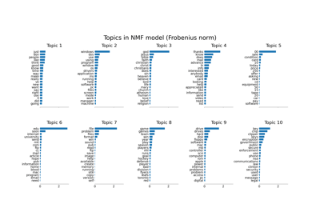

Topic extraction with Non-negative Matrix Factorization and Latent Dirichlet Allocation

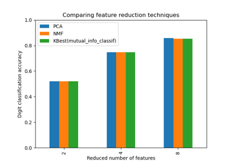

Selecting dimensionality reduction with Pipeline and GridSearchCV

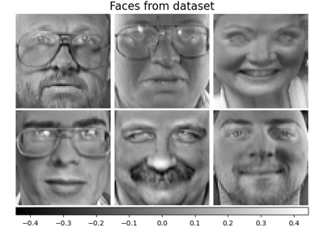

Faces dataset decompositions

© 2007–2026 The scikit-learn developers  
Licensed under the 3-clause BSD License.  
https://scikit-learn.org/1.9/modules/generated/sklearn.decomposition.NMF.html